# WKB Exercises

## Support materials for Perturbation Methods using backward error

### by Corless & Fillion

#### to be published by SIAM

Copyright (c) 2024 Robert M. Corless

Permission is hereby granted, free of charge, to any person obtaining a copy of this software and associated documentation files (the “Software”), to deal in the Software without restriction, including without limitation the rights to use, copy, modify, merge, publish, distribute, sublicense, and/or sell copies of the Software, and to permit persons to whom the Software is furnished to do so, subject to the following conditions:

The above copyright notice and this permission notice shall be included in all copies or substantial portions of the Software.

THE SOFTWARE IS PROVIDED “AS IS”, WITHOUT WARRANTY OF ANY KIND, EXPRESS OR IMPLIED, INCLUDING BUT NOT LIMITED TO THE WARRANTIES OF MERCHANTABILITY, FITNESS FOR A PARTICULAR PURPOSE AND NONINFRINGEMENT. IN NO EVENT SHALL THE AUTHORS OR COPYRIGHT HOLDERS BE LIABLE FOR ANY CLAIM, DAMAGES OR OTHER LIABILITY, WHETHER IN AN ACTION OF CONTRACT, TORT OR OTHERWISE, ARISING FROM, OUT OF OR IN CONNECTION WITH THE SOFTWARE OR THE USE OR OTHER DEALINGS IN THE SOFTWARE.

$\newcommand{\yWKB}{{y_{\mathrm{WKB}}}}$ $\newcommand{\yref}{{y_{\mathrm{ref}}}}$ $\newcommand{\e}{{\varepsilon}}$ The following routine gives us the building blocks for the solutions of the exercises.

```python
WKB2Q := proc( Q::operator, x, eps, {a:=0})
 local xi, residual, S, y;
 S := int( sqrt(Q(xi)), xi=a..x ) ;
 y := exp(S/eps)*Q(x)^(-1/4);
 residual := simplify( eps^2*diff(y,x,x)/y-Q(x));
 y := [y ,exp(-S/eps)*Q(x)^(-1/4)];
 return y, residual
end:
```

```
kilobytes used=1825, alloc=5424, time=0.31
```

Before we begin, we compute the WKB solution and accessories for our example problem $\e^2y'' = (1+x)y$ with boundary conditions $y(0)=1$ and $y(x) \to 0$ as $x \to \infty$.

```python
(yc,resc) := WKB2Q( t->-1-t, x, ep ) assuming x>-1, x<1;
```

```
kilobytes used=4677, alloc=13872, time=0.80
```

| exp((-2/3*I+2/3*I*(1+x)^(3/2))/varepsilon)/(-1-x)^(1/4) | exp(-(-2/3*I+2/3*I*(1+x)^(3/2))/varepsilon)/(-1-x)^(1/4) |
| --- | --- |

,$$\frac{5 \varepsilon^{2}}{16 \left(1+x \right)^{2}}$$

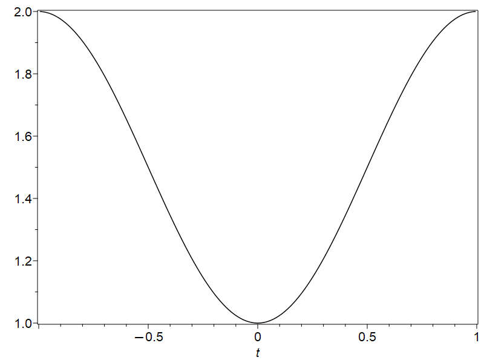

```python
plot( 2-cos(Pi*t/2)^2, t=-1..1 );
```

```python
macro(ep=varepsilon);
(y0,res0) := WKB2Q( x->1+x, x, ep, a=-1);
```

```
                                      ep
```

| exp(2/3*(1+x)^(3/2)/varepsilon)/(1+x)^(1/4) | exp(-2/3*(1+x)^(3/2)/varepsilon)/(1+x)^(1/4) |
| --- | --- |

,$$\frac{5 \varepsilon^{2}}{16 \left(1+x \right)^{2}}$$

```python
yics := eval(y0, x=0);
```

| exp(2/3/varepsilon) | exp(-2/3/varepsilon) |
| --- | --- |

```python
Wronskian := limit( y0[1]*diff(y0[2],x) - y0[2]*diff(y0[1],x), x=0, right);
```

$$-\frac{2}{\varepsilon}$$

$-C$ times the Wronskian is $1/\e^2$ so $$ C = -\frac{1}{\e^2 \mathrm{Wronskian}}. $$

Therefore we can take $K_1=0$ and $K_2=1$ to get our desired solution.

```python
y0op := [unapply(y0[1]/yics[1],x),unapply(y0[2]/yics[2],x)];
C := simplify(-1/(ep^2*Wronskian));
```

```
                                  varepsilon
```

$$\frac{1}{2 \varepsilon}$$

```python
G0 := (x,xi) -> piecewise( x<xi, y0op[2](xi)*(y0op[1](x)-y0op[2](x))*C,
                       (y0op[1](xi)-y0op[2](xi))*y0op[2](x)*C );
```

```
(x, xi) -> piecewise(x < xi,y0op[2](xi)*(y0op[1](x)-y0op[2](x))*C,(y0op[1](xi)-y0op[2](xi))*y0op[2](x)*C)
```

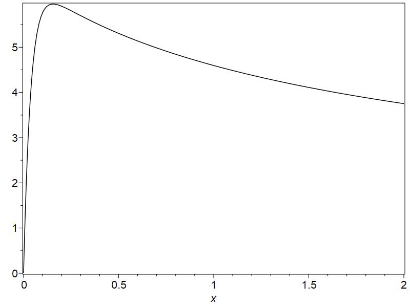

```python
plot(eval( G0(x,x),ep=1/13), x=0..2 );
```

```
kilobytes used=12176, alloc=20842, time=1.77
```

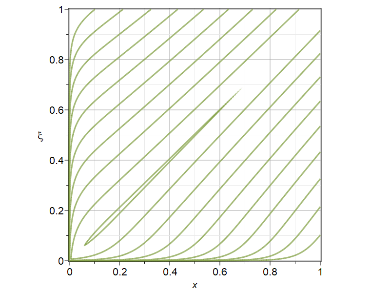

```python
plots[contourplot](eval( G0(x,xi),ep=1/13), x=0..1, xi=0..1,
grid=[400,400], contours=[seq(5^(k), k=-8..1)], colour="Executive Green",
thickness=3, gridlines, labels=[x,xi], scaling=constrained );
```

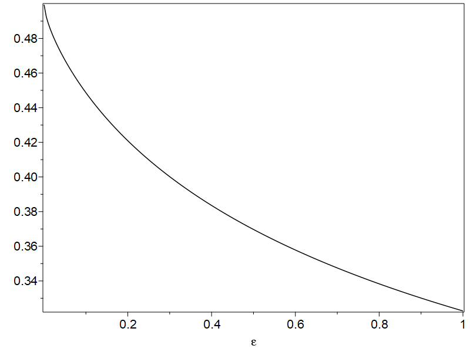

```python
plot(ep^(1)*G0(ep^(2/3),ep^(2/3)), ep=0.0001..1 );
```

```python
MultiSeries:-series( ( G0(ep^(2/3),ep^(2/3))), ep,2 ) assuming ep>0, ep<1;
```

Use the WKB method to approximately solve $\e^2 y'' = Q(x)y$, $y(0)=1$ and $y(x) \to 0$ as $x \to \infty$, where

1. $Q(x) = \cosh(x)$ (the integral is an elliptic function)
2. $Q(x) = \exp(x)/2$ (this is related to the aging spring\index{aging spring})
3. $Q(x) = 1+x^4$ (this integral is a bit horrible)

In each case compute the residual $\e^2((Q''/4Q) - 5(Q'/4Q)^2)\yWKB$ and the resulting altered potential $\widetilde{Q}$.

```python
(y1,res1) := WKB2Q( x->cosh(x), x, varepsilon ) assuming x>0;
```

```
kilobytes used=36344, alloc=19504, time=6.95
```

| exp(2^(1/2)*EllipticPi(((cosh(x)-1)/cosh(x))^(1/2),1,1/2*2^(1/2))/varepsilon)/cosh(x)^(1/4) | exp(-2^(1/2)*EllipticPi(((cosh(x)-1)/cosh(x))^(1/2),1,1/2*2^(1/2))/varepsilon)/cosh(x)^(1/4) |
| --- | --- |

,$$-\frac{\varepsilon^{2} \left(5 \mathrm{sech}\left(x \right)^{2}-1\right)}{16}$$

```python
eval(y1, x=0);
```

| 1 | 1 |
| --- | --- |

```python
Wronskian := limit( y1[1]*diff(y1[2],x) - y1[2]*diff(y1[1],x), x=0, right);
```

$$-\frac{2}{\varepsilon}$$

We will find $O(1/\varepsilon)$ behaviour always, because $y' = O(1/\varepsilon)$.

```python
evalf( eval( y1, [x=2.0, varepsilon=1/13.]) );
```

| 536277704801069. | .961367789748899e-15 |
| --- | --- |

This suggests again that we can take $K_1=0$ and $K_2=1$ to get our desired solution.

```
kilobytes used=87138, alloc=19658, time=11.52
```

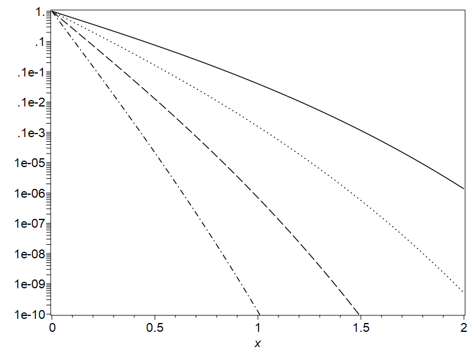

```python
plots[logplot]( [seq(eval(y1[2],varepsilon=ep), ep=[1/5,1/8,1/13,1/21])],
x=0..2,
linestyle=[1,2,3,4],
view=[0..2, 1.0e-10..1.0]
);
```

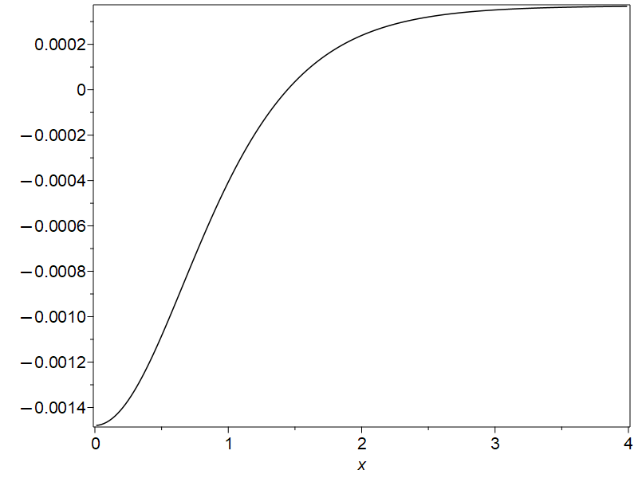

```python
plot(eval(res1,varepsilon=1/13), x=0..4 );
```

That suggests that the solution is quite accurate, even when $\e = 1/13$.

```python
macro(ep=varepsilon):
(y2,res2) := WKB2Q( x->exp(x)/2, x, ep);
```

| exp((-2^(1/2)+2^(1/2)*exp(x)^(1/2))/varepsilon)*2^(1/4)/exp(x)^(1/4) | exp(-(-2^(1/2)+2^(1/2)*exp(x)^(1/2))/varepsilon)*2^(1/4)/exp(x)^(1/4) |
| --- | --- |

,$$\frac{\varepsilon^{2}}{16}$$

```python
latex(y2[2]);
```

```
\frac{{\mathrm e}^{-\frac{-\sqrt{2}+\sqrt{2} \sqrt{{\mathrm e}^{x}}}{\varepsilon}} 2^{\frac{1}{4}}}{\left({\mathrm e}^{x}\right)^{\frac{1}{4}}}
```

```python
eval(y2, x=0);
```

| 2^(1/4) | 2^(1/4) |
| --- | --- |

```python
Wronskian := limit( y2[1]*diff(y2[2],x) - y2[2]*diff(y2[1],x), x=0, right);
```

$$-\frac{2}{\varepsilon}$$

```python
y2[1];
```

$$\frac{{\mathrm e}^{\frac{-\sqrt{2}+\sqrt{2} \sqrt{{\mathrm e}^{x}}}{\varepsilon}} 2^{\frac{1}{4}}}{\left({\mathrm e}^{x}\right)^{\frac{1}{4}}}$$

```python
y2[2];
```

$$\frac{{\mathrm e}^{-\frac{-\sqrt{2}+\sqrt{2} \sqrt{{\mathrm e}^{x}}}{\varepsilon}} 2^{\frac{1}{4}}}{\left({\mathrm e}^{x}\right)^{\frac{1}{4}}}$$

The boundary conditions require that $\yWKB = 2^{-1/4}y_2$. The residual is constant, $\e^2/16$. We have the *exact* solution of a problem with potential $\widetilde{Q} = \exp(x)/2 + \e^2/16$. Surely this tells us everything that we could want to know. The fact that these are similar to the solutions of the first problem is not a coincidence, because $\cosh(x) \sim \exp(x)/2$ for large $x$.

```
kilobytes used=100136, alloc=19658, time=12.67
```

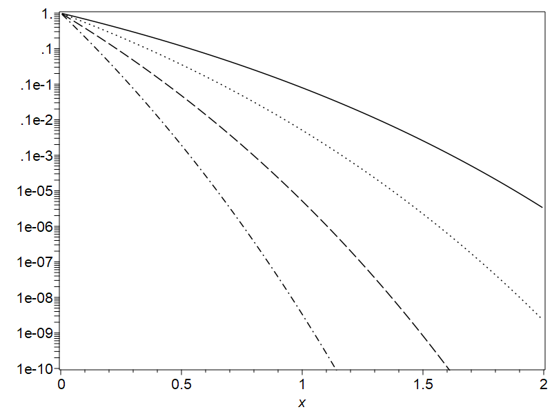

```python
plots[logplot]( [seq(eval(2^(-1/4)*y2[2],varepsilon=ep), ep=[1/5,1/8,1/13,1/21])],
x=0..2,
linestyle=[1,2,3,4],
view=[0..2, 1.0e-10..1.0]
);
```

```python
(y3,res3) := WKB2Q( x->1+x^4, x, varepsilon ):
y3[1];
```

$$\frac{{\mathrm e}^{\frac{\left(\frac{1}{12}-\frac{\mathrm{I}}{12}\right) \left(\mathrm{I} \sqrt{2} x^{5}+\sqrt{2} x^{5}+4 \sqrt{1-\mathrm{I} x^{2}} \sqrt{1+\mathrm{I} x^{2}} F\left(\left(\frac{1}{2}+\frac{\mathrm{I}}{2}\right) x \sqrt{2}, \mathrm{I}\right)+\mathrm{I} x \sqrt{2}+x \sqrt{2}\right) \sqrt{2}}{\sqrt{x^{4}+1} \varepsilon}}}{\left(x^{4}+1\right)^{\frac{1}{4}}}$$

```python
Wronskian := limit( y3[1]*diff(y3[2],x) - y3[2]*diff(y3[1],x), x=0, right);
```

$$-\frac{2}{\varepsilon}$$

```python
latex(factor(evalc(res3))); # As usual, seems simple (strange that it has I in it, though)
```

```
\frac{\left(2 x^{4}-3\right) x^{2} \varepsilon^{2}}{\left(x^{4}+1\right)^{2}}
```

```python
eval(y3,x=0);
```

| 1 | 1 |
| --- | --- |

```python
evalf(eval(y3,[x=1.,ep=1/13.]));
```

| 1189799.75376707+0.*I | .594307385715746e-6+0.*I |
| --- | --- |

Again it is $y_2$ that is the decaying one.

```
kilobytes used=128920, alloc=23754, time=15.73
```

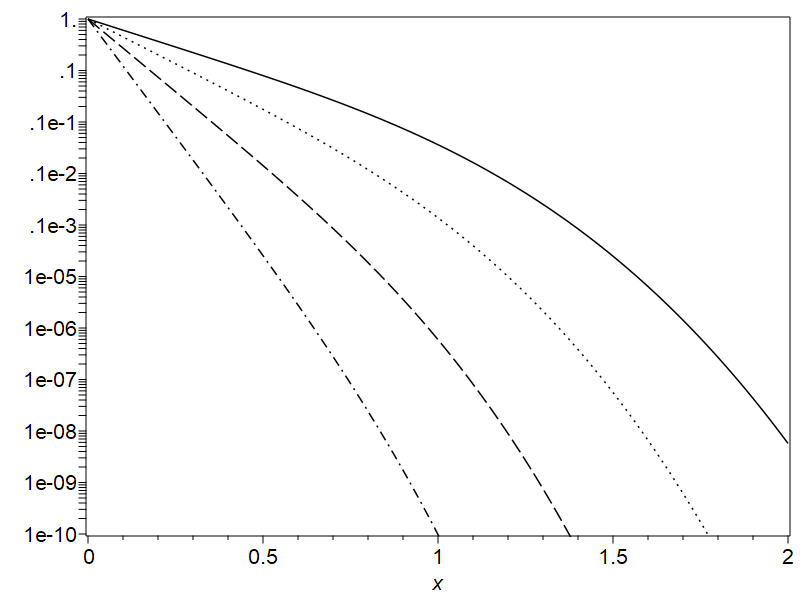

```python
plots[logplot]( [seq(eval(y3[2],varepsilon=ep), ep=[1/5,1/8,1/13,1/21])],
x=0..2,
linestyle=[1,2,3,4],
view=[0..2, 1.0e-10..1.0]
);
```

That graph looks visibly different to the last one.

Next question: compute an approximate Green's function for all of those. Luckily the boundary conditions are the same, so we may do them all the same way. Since $y_1(0)=y_2(0)$ every time, we must have the Green's function being $K_1(\xi)(y_1(x)-y_2(x))$ if $0 \le x < \xi$. Since only $y_2(x)$ goes to zero as $x \to \infty$, we must have the Green's function being $K_2(\xi)y_2(x)$ if $\xi < x < \infty$. By continuity, $K_1(\xi) = C y_2(\xi)$ and $K_2(\xi) = C(y_1(\xi)-y_2(\xi))$ for some constant $C$. By the jump condition $G_x^+-G_x^- = 1/\e^2$ we can identify $C$. Doing the subtraction we see the Wronskian appearing:

$$ -C \times \mathrm{Wronskian} = \frac{1}{\e^2} $$

Since the Wronskian was $-2/\e$ every time (surely a coincidence?) we get the same $C=1/(2\e)$.

```python
y1op := [unapply(y1[1],x),unapply(y1[2],x)];
y2op := [unapply(y2[1],x),unapply(y2[2],x)];
y3op := [unapply(y3[1],x),unapply(y3[2],x)];

G1 := (x,xi) -> piecewise( x<xi, y1op[2](xi)*(y1op[1](x)-y1op[2](x))/2/ep,
                       (y1op[1](xi)-y1op[2](xi))*y1op[2](x)/2/ep );
G2 := (x,xi) -> piecewise( x<xi, y2op[2](xi)*(y2op[1](x)-y2op[2](x))/2/ep,
                       (y2op[1](xi)-y2op[2](xi))*y2op[2](x)/2/ep );
G3 := (x,xi) -> piecewise( x<xi, y3op[2](xi)*(y3op[1](x)-y3op[2](x))/2/ep,
                       (y3op[1](xi)-y3op[2](xi))*y3op[2](x)/2/ep );
```

```
                          varepsilon
```

```
kilobytes used=622729, alloc=27851, time=56.97
```

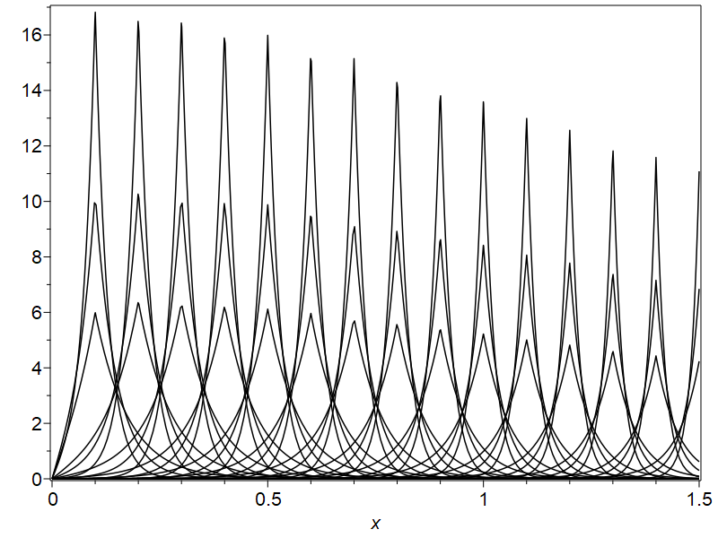

```python
plot( [seq(seq(eval(G1(x,xs),ep=es),
               es=[1/13,1/21,1/34]),
               xs=[seq(k/10,k=1..15)])],
     x=0..1.5, view=[0..1.5,0..17]);
```

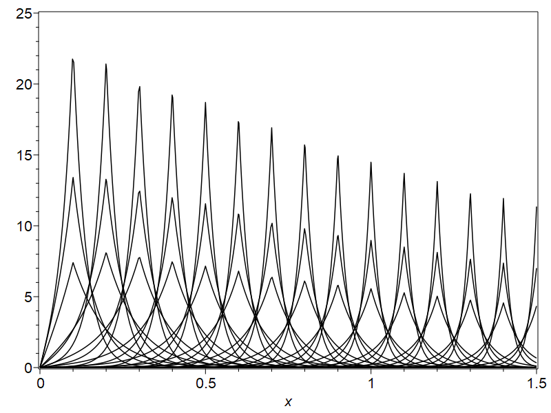

```python
plot( [seq(seq(eval(G2(x,xs),ep=es),
               es=[1/13,1/21,1/34]),
               xs=[seq(k/10,k=1..15)])],
     x=0..1.5, view=[0..1.5,0..25]);
```

```
kilobytes used=985097, alloc=25802, time=91.02
```

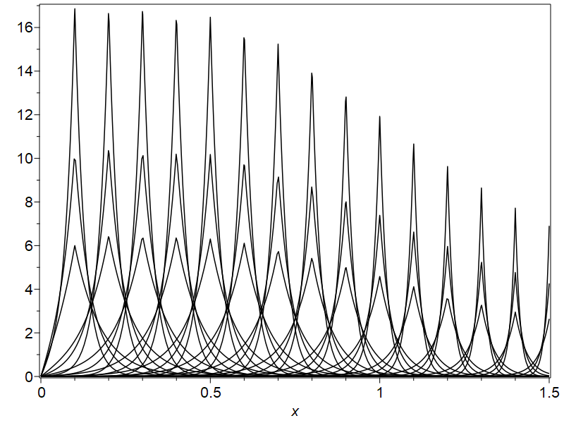

```python
plot( [seq(seq(eval(G3(x,xs),ep=es),
               es=[1/13,1/21,1/34]),
               xs=[seq(k/10,k=1..15)])],
     x=0..1.5, view=[0..1.5,0..17]);
```

```python
1/sqrt(21.);
```

$$ 0.218217890235992$$

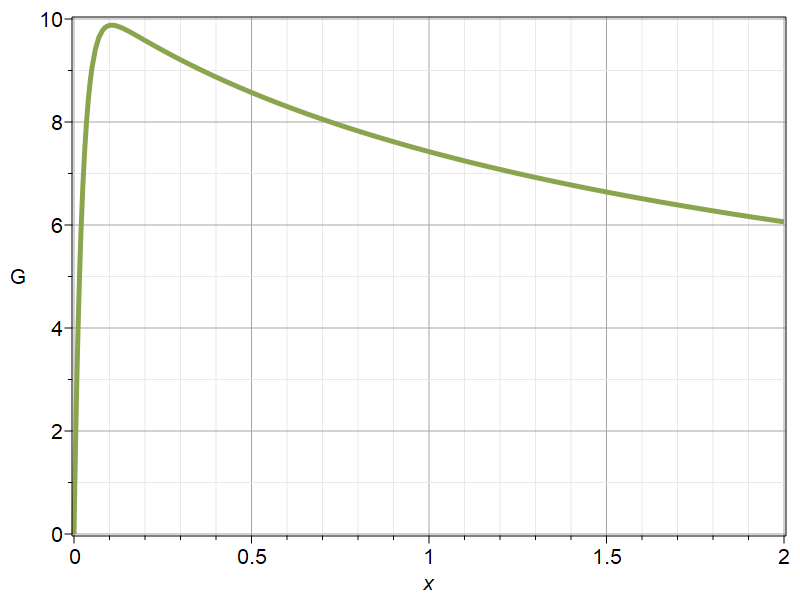

```python
plot( eval(G0(xi,xi),ep=1/21), xi=0..2.0, view=[0..2.0,0..10],
      thickness=5, colour="Executive Green", gridlines, labels=[x,"G"] );
```

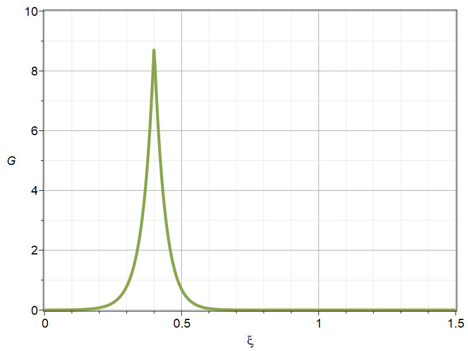

```python
plot( eval(G0(0.4,xi),ep=1/21),xi=0..1.5, view=[0..1.5, 0..10],
      thickness=5, colour="Executive Green", gridlines, labels=[xi,G] );
```

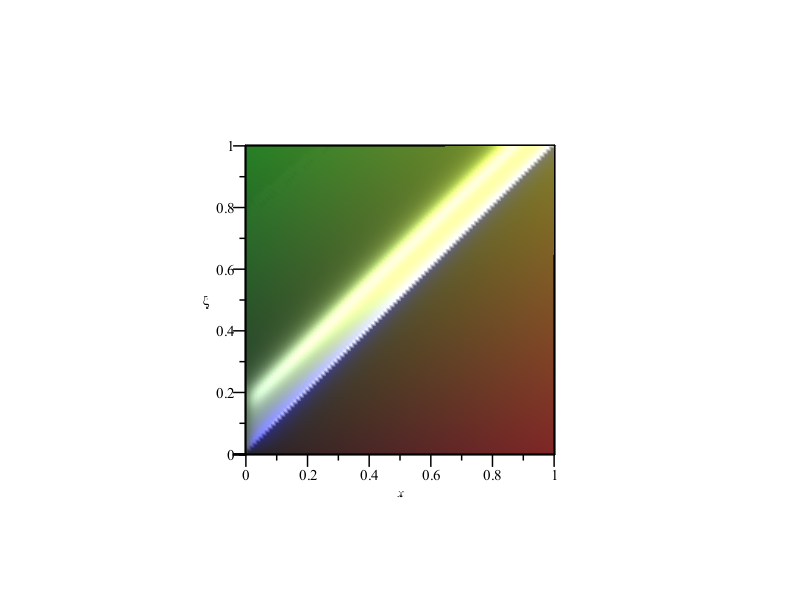

```python
plot3d( eval(G1(x,xi),ep=1/21), x=0..1, xi=0..1,
        grid=[100,100],style=surfacecontour, orientation=[-90,0] );
```

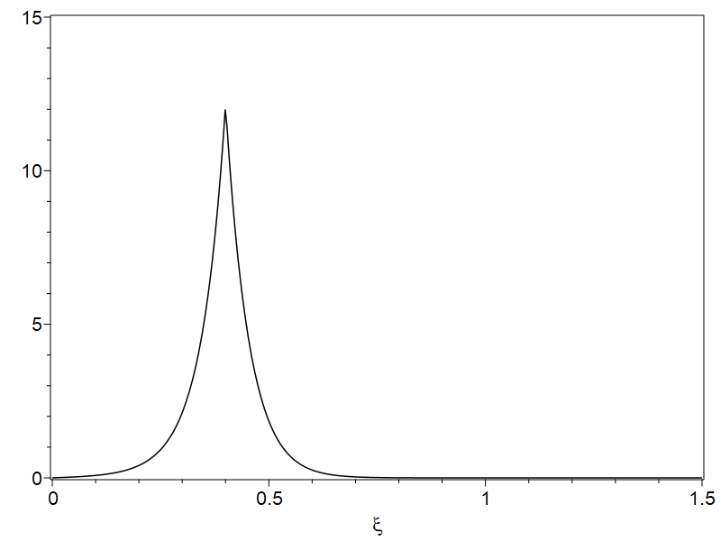

```python
plot( eval(G2(0.4,xi),ep=1/21),xi=0..1.5, view=[0..1.5, 0..15] );
```

```
kilobytes used=1002227, alloc=25802, time=92.88
```

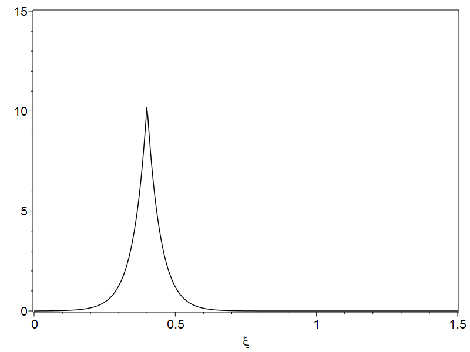

```python
plot( eval(G3(0.4,xi),ep=1/21),xi=0..1.5, view=[0..1.5, 0..15] );
```

```python
res1; # This is Q[2]
```

```
                      - 1/16 varepsilon  (5 sech(x)  - 1)
```

$$-\frac{\varepsilon^{2} \left(5 \mathrm{sech}\left(x \right)^{2}-1\right)}{16}$$

The following integral needs some care to deal with.

```python
F1 := simplify( int( res1/ep^2/sqrt(cosh(x))/2, x=0..X) ) assuming X>0;
```

$$-\frac{5 \sinh \left(X \right)}{48 \cosh \left(X \right)^{\frac{3}{2}}}-\frac{\sqrt{2} F\left(\sqrt{1-\mathrm{sech}\left(X \right)}, \frac{\sqrt{2}}{2}\right)}{48}$$

```
kilobytes used=1020673, alloc=25802, time=95.09
```

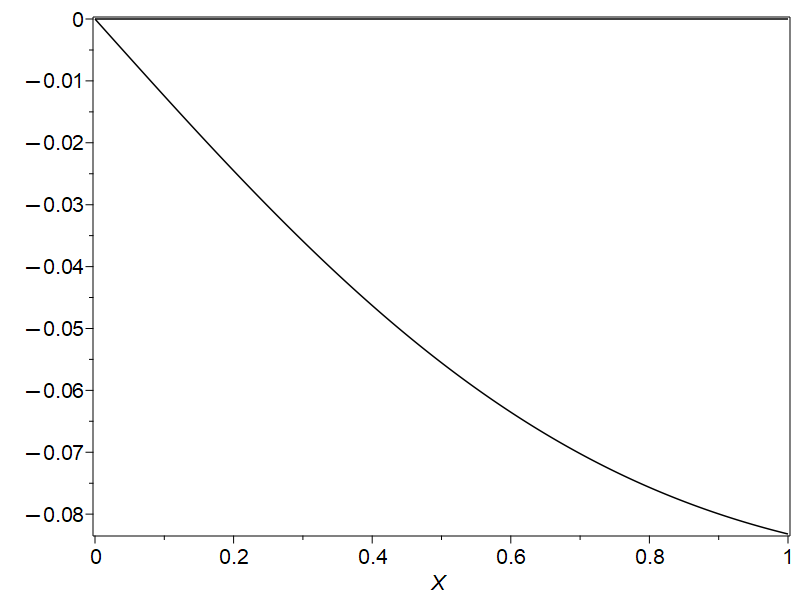

```python
plot( [Re(F1),Im(F1)], X=0..1 );
```

The following updates the $Q^{-1/4}$ factor as well. For this example $Q(x) = \cosh x$.

```python
better1 := y1[1]*exp(-ep*eval(F1,X=x))*(cosh(x)-res1)^(-1/4)/cosh(x)^(-1/4):
betterres1 := simplify(ep^2*diff(better1,x,x)/better1 - cosh(x)) assuming x>0, ep>0;
```

```
kilobytes used=1104069, alloc=28208, time=104.59
```

$$\frac{-\frac{25 \sqrt{2} \sinh \left(x \right) \left(\frac{256 \sinh \left(x \right)^{3} \cosh \left(x \right)^{\frac{17}{2}} \varepsilon}{5}+\frac{\sinh \left(x \right)^{2} \left(\left(-96 \varepsilon^{2}-1280\right) \sinh \left(x \right)+\varepsilon^{4} \tanh \left(x \right)\right) \varepsilon \cosh \left(x \right)^{\frac{15}{2}}}{25}-\frac{\sinh \left(x \right)^{2} \left(\left(-96 \varepsilon^{2}+11520\right) \sinh \left(x \right)+\varepsilon^{4} \tanh \left(x \right)\right) \varepsilon \cosh \left(x \right)^{\frac{13}{2}}}{25}+\frac{208 \sinh \left(x \right)^{3} \left(\varepsilon^{2}+\frac{144}{13}\right) \varepsilon \cosh \left(x \right)^{\frac{11}{2}}}{5}+\varepsilon^{3} \sinh \left(x \right)^{2} \left(\varepsilon^{2} \tanh \left(x \right)+144 \sinh \left(x \right)\right) \cosh \left(x \right)^{\frac{5}{2}}-\varepsilon^{3} \sinh \left(x \right)^{2} \left(\varepsilon^{2} \tanh \left(x \right)+144 \sinh \left(x \right)\right) \cosh \left(x \right)^{\frac{7}{2}}-\frac{208 \sinh \left(x \right)^{3} \cosh \left(x \right)^{\frac{9}{2}} \varepsilon^{3}}{5}+\frac{\left(\cosh \left(x \right)+1\right) \left(\cosh \left(x \right)^{2}-3\right) \left(\cosh \left(x \right)-1\right)^{2} \left(\varepsilon^{2}+48 \cosh \left(x \right)\right) \left(\varepsilon^{2} \cosh \left(x \right)^{2}-16 \cosh \left(x \right)^{3}-5 \varepsilon^{2}\right)^{2}}{120}\right) \sqrt{2+2 \,\mathrm{sech}\left(x \right)} \varepsilon^{2} \sqrt{1-\mathrm{sech}\left(x \right)}}{192}-\frac{75 \left(-\frac{25 \varepsilon^{2} \mathrm{sech}\left(x \right)^{\frac{17}{2}}}{12}+\left(5 \varepsilon^{2}+\frac{40}{3}\right) \mathrm{sech}\left(x \right)^{\frac{13}{2}}+\mathrm{sech}\left(x \right)^{\frac{5}{2}} \varepsilon^{2}-\frac{23 \mathrm{sech}\left(x \right)^{\frac{9}{2}} \varepsilon^{2}}{6}-\frac{4 \sinh \left(x \right) \varepsilon}{3}+\frac{56 \mathrm{sech}\left(x \right)^{\frac{5}{2}}}{3}-\frac{88 \mathrm{sech}\left(x \right)^{\frac{9}{2}}}{3}\right) \varepsilon^{6} \cosh \left(x \right)^{\frac{13}{2}}}{256}-\frac{25 \left(-\frac{25 \varepsilon^{4} \mathrm{sech}\left(x \right)^{\frac{17}{2}}}{12}+\left(5 \varepsilon^{4}-20 \varepsilon^{2}\right) \mathrm{sech}\left(x \right)^{\frac{13}{2}}+\left(\varepsilon^{4}-28 \varepsilon^{2}-64\right) \mathrm{sech}\left(x \right)^{\frac{5}{2}}+\left(-\frac{23}{6} \varepsilon^{4}+44 \varepsilon^{2}+32\right) \mathrm{sech}\left(x \right)^{\frac{9}{2}}+2 \sinh \left(x \right) \left(\varepsilon^{2}+\frac{176}{5}\right) \varepsilon \right) \varepsilon^{4} \cosh \left(x \right)^{\frac{15}{2}}}{128}-\frac{\varepsilon^{3} \left(35 \mathrm{sech}\left(x \right)^{\frac{11}{2}} \varepsilon^{5} \sinh \left(x \right)^{2}+\mathrm{sech}\left(x \right)^{\frac{3}{2}} \varepsilon^{5} \sinh \left(x \right)^{2}-11 \mathrm{sech}\left(x \right)^{\frac{7}{2}} \varepsilon^{5} \sinh \left(x \right)^{2}-25 \mathrm{sech}\left(x \right)^{\frac{15}{2}} \varepsilon^{5} \sinh \left(x \right)^{2}+\left(\frac{1875}{2} \varepsilon^{5}+14400 \varepsilon^{3}\right) \mathrm{sech}\le…

```python
puzzle := map(simplify, series(betterres1, ep, 4) ) assuming x>0, ep>0;
```

```
kilobytes used=1119484, alloc=28208, time=106.42
```

$$\frac{-\frac{5 \sinh \left(x \right)^{3} \sqrt{2} \sqrt{2+2 \,\mathrm{sech}\left(x \right)} \left(\cosh \left(x \right)-1\right) \left(\cosh \left(x \right)^{2}-3\right) \sqrt{1-\mathrm{sech}\left(x \right)}}{4}+\left(-\sinh \left(x \right)^{2} \mathrm{sech}\left(x \right)^{\frac{7}{2}}+\sinh \left(x \right)^{2} \mathrm{sech}\left(x \right)^{\frac{3}{2}}+15 \mathrm{sech}\left(x \right)^{\frac{13}{2}}-\frac{63 \mathrm{sech}\left(x \right)^{\frac{9}{2}}}{2}+18 \mathrm{sech}\left(x \right)^{\frac{5}{2}}\right) \cosh \left(x \right)^{\frac{11}{2}}+\left(-30 \mathrm{sech}\left(x \right)^{\frac{13}{2}}+\frac{93 \mathrm{sech}\left(x \right)^{\frac{9}{2}}}{2}-18 \mathrm{sech}\left(x \right)^{\frac{5}{2}}+15 \sinh \left(x \right)^{2} \mathrm{sech}\left(x \right)^{\frac{11}{2}}-15 \sinh \left(x \right)^{2} \mathrm{sech}\left(x \right)^{\frac{15}{2}}\right) \cosh \left(x \right)^{\frac{13}{2}}+\left(-\frac{15 \cosh \left(x \right)^{\frac{7}{2}}}{2}+\frac{15 \cosh \left(x \right)^{\frac{9}{2}}}{2}-15 \cosh \left(x \right)^{\frac{17}{2}}\right) \mathrm{sech}\left(x \right)^{\frac{9}{2}}-15 \sinh \left(x \right)^{2} \left(\mathrm{sech}\left(x \right)^{\frac{15}{2}}+\mathrm{sech}\left(x \right)^{\frac{17}{2}}-\mathrm{sech}\left(x \right)^{\frac{19}{2}}\right) \cosh \left(x \right)^{\frac{17}{2}}+\left(-\sinh \left(x \right)^{2} \mathrm{sech}\left(x \right)^{\frac{3}{2}}+\sinh \left(x \right)^{2} \mathrm{sech}\left(x \right)^{\frac{7}{2}}-15 \mathrm{sech}\left(x \right)^{\frac{5}{2}}\right) \cosh \left(x \right)^{\frac{9}{2}}+15 \cosh \left(x \right)^{\frac{7}{2}} \mathrm{sech}\left(x \right)^{\frac{5}{2}}+15 \cosh \left(x \right)^{\frac{21}{2}} \mathrm{sech}\left(x \right)^{\frac{13}{2}}+\frac{3 \cosh \left(x \right)^{3} \left(\cosh \left(x \right)-1\right) \left(\cosh \left(x \right)^{2}+5\right)}{2}}{24 \cosh \left(x \right)^{\frac{3}{2}} \sqrt{\mathrm{sech}\left(x \right)} \left(\cosh \left(x \right)-1\right)^{3} \left(\cosh \left(x \right)+1\right)^{2}} \varepsilon^{2}+\frac{15}{64} \frac{\sinh \left(x \right) \left(\left(\sqrt{\cosh \left(x \right)}-\frac{\cosh \left(x \right)^{\frac{5}{2}}}{9}\right) \sqrt{2} \sqrt{2+2 \,\mathrm{sech}\left(x \right)} \sinh \left(x \right)^{3} \sqrt{1-\mathrm{sech}\left(x \right)}+\frac{2 \cosh \left(x \right)^{\frac{11}{2}}}{9}-2 \cosh \left(x \right)^{\frac{7}{2}}+\left(-\frac{4 \cosh \left(x \right)^{6}}{9}+4 \cosh \left(x \right)^{4}\right) \mathrm{sech}\left(x \right)^{\frac{5}{2}}+\left(\frac{2 \cosh \left(x \right)^{6}}{9}-2 \cosh \left(x \right)^{4}\right) \mathrm{sech}\left(x \right)^{\frac{9}{2}}\right)}{\cosh \left(x \right)^{\frac{7}{2}} \sqrt{\mathrm{sech}\left(x \right)} \left(\cosh \left(x \right)+1\right)^{2} \left(\cosh \left(x \right)-1\right)^{2}} \varepsilon^{3}+\mathrm{O}\left(\varepsilon^{4}\right)$$

```python
bad := coeff(puzzle,ep,2);
```

$$\frac{-\frac{5 \sinh \left(x \right)^{3} \sqrt{2} \sqrt{2+2 \,\mathrm{sech}\left(x \right)} \left(\cosh \left(x \right)-1\right) \left(\cosh \left(x \right)^{2}-3\right) \sqrt{1-\mathrm{sech}\left(x \right)}}{4}+\left(-\sinh \left(x \right)^{2} \mathrm{sech}\left(x \right)^{\frac{7}{2}}+\sinh \left(x \right)^{2} \mathrm{sech}\left(x \right)^{\frac{3}{2}}+15 \mathrm{sech}\left(x \right)^{\frac{13}{2}}-\frac{63 \mathrm{sech}\left(x \right)^{\frac{9}{2}}}{2}+18 \mathrm{sech}\left(x \right)^{\frac{5}{2}}\right) \cosh \left(x \right)^{\frac{11}{2}}+\left(-30 \mathrm{sech}\left(x \right)^{\frac{13}{2}}+\frac{93 \mathrm{sech}\left(x \right)^{\frac{9}{2}}}{2}-18 \mathrm{sech}\left(x \right)^{\frac{5}{2}}+15 \sinh \left(x \right)^{2} \mathrm{sech}\left(x \right)^{\frac{11}{2}}-15 \sinh \left(x \right)^{2} \mathrm{sech}\left(x \right)^{\frac{15}{2}}\right) \cosh \left(x \right)^{\frac{13}{2}}+\left(-\frac{15 \cosh \left(x \right)^{\frac{7}{2}}}{2}+\frac{15 \cosh \left(x \right)^{\frac{9}{2}}}{2}-15 \cosh \left(x \right)^{\frac{17}{2}}\right) \mathrm{sech}\left(x \right)^{\frac{9}{2}}-15 \sinh \left(x \right)^{2} \left(\mathrm{sech}\left(x \right)^{\frac{15}{2}}+\mathrm{sech}\left(x \right)^{\frac{17}{2}}-\mathrm{sech}\left(x \right)^{\frac{19}{2}}\right) \cosh \left(x \right)^{\frac{17}{2}}+\left(-\sinh \left(x \right)^{2} \mathrm{sech}\left(x \right)^{\frac{3}{2}}+\sinh \left(x \right)^{2} \mathrm{sech}\left(x \right)^{\frac{7}{2}}-15 \mathrm{sech}\left(x \right)^{\frac{5}{2}}\right) \cosh \left(x \right)^{\frac{9}{2}}+15 \cosh \left(x \right)^{\frac{7}{2}} \mathrm{sech}\left(x \right)^{\frac{5}{2}}+15 \cosh \left(x \right)^{\frac{21}{2}} \mathrm{sech}\left(x \right)^{\frac{13}{2}}+\frac{3 \cosh \left(x \right)^{3} \left(\cosh \left(x \right)-1\right) \left(\cosh \left(x \right)^{2}+5\right)}{2}}{24 \cosh \left(x \right)^{\frac{3}{2}} \sqrt{\mathrm{sech}\left(x \right)} \left(\cosh \left(x \right)-1\right)^{3} \left(\cosh \left(x \right)+1\right)^{2}}$$

```python
Digits := 30;
evalf(eval(bad,x=1.3));
```

```
                                 Digits := 30
```

$${ 1.1\times 10^{-30}}$$

```python
progress := combine(bad,trig) assuming x>0;
```

$$\frac{420+960 \mathrm{sech}\left(x \right)^{\frac{15}{2}} \cosh \left(x \right)^{\frac{17}{2}}-960 \cosh \left(x \right)^{\frac{7}{2}} \mathrm{sech}\left(x \right)^{\frac{9}{2}}+64 \mathrm{sech}\left(x \right)^{\frac{3}{2}} \cosh \left(x \right)^{\frac{9}{2}}+960 \cosh \left(x \right)^{\frac{13}{2}} \mathrm{sech}\left(x \right)^{\frac{15}{2}}-3840 \cosh \left(x \right)^{\frac{13}{2}} \mathrm{sech}\left(x \right)^{\frac{13}{2}}-960 \cosh \left(x \right)^{\frac{13}{2}} \mathrm{sech}\left(x \right)^{\frac{11}{2}}+5952 \cosh \left(x \right)^{\frac{13}{2}} \mathrm{sech}\left(x \right)^{\frac{9}{2}}+1920 \cosh \left(x \right)^{\frac{11}{2}} \mathrm{sech}\left(x \right)^{\frac{13}{2}}-4032 \cosh \left(x \right)^{\frac{11}{2}} \mathrm{sech}\left(x \right)^{\frac{9}{2}}+64 \cosh \left(x \right)^{\frac{11}{2}} \mathrm{sech}\left(x \right)^{\frac{7}{2}}+2304 \cosh \left(x \right)^{\frac{11}{2}} \mathrm{sech}\left(x \right)^{\frac{5}{2}}-64 \cosh \left(x \right)^{\frac{9}{2}} \mathrm{sech}\left(x \right)^{\frac{7}{2}}-1920 \cosh \left(x \right)^{\frac{9}{2}} \mathrm{sech}\left(x \right)^{\frac{5}{2}}-960 \cosh \left(x \right)^{\frac{17}{2}} \mathrm{sech}\left(x \right)^{\frac{19}{2}}+960 \cosh \left(x \right)^{\frac{17}{2}} \mathrm{sech}\left(x \right)^{\frac{17}{2}}-64 \mathrm{sech}\left(x \right)^{\frac{3}{2}} \cosh \left(x \right)^{\frac{11}{2}}+570 \cosh \left(2 x \right)-12 \cosh \left(5 x \right)+156 \cosh \left(4 x \right)-300 \cosh \left(3 x \right)+6 \cosh \left(6 x \right)+340 \sqrt{2} \sqrt{2+2 \,\mathrm{sech}\left(x \right)} \sqrt{1-\mathrm{sech}\left(x \right)} \sinh \left(x \right)-5 \sqrt{2} \sqrt{2+2 \,\mathrm{sech}\left(x \right)} \sqrt{1-\mathrm{sech}\left(x \right)} \sinh \left(6 x \right)+960 \cosh \left(2 x \right) \cosh \left(x \right)^{\frac{13}{2}} \mathrm{sech}\left(x \right)^{\frac{11}{2}}+64 \cosh \left(2 x \right) \cosh \left(x \right)^{\frac{9}{2}} \mathrm{sech}\left(x \right)^{\frac{7}{2}}+960 \cosh \left(2 x \right) \cosh \left(x \right)^{\frac{17}{2}} \mathrm{sech}\left(x \right)^{\frac{19}{2}}-960 \cosh \left(2 x \right) \cosh \left(x \right)^{\frac{17}{2}} \mathrm{sech}\left(x \right)^{\frac{17}{2}}+64 \cosh \left(2 x \right) \cosh \left(x \right)^{\frac{11}{2}} \mathrm{sech}\left(x \right)^{\frac{3}{2}}-64 \cosh \left(2 x \right) \cosh \left(x \right)^{\frac{9}{2}} \mathrm{sech}\left(x \right)^{\frac{3}{2}}-64 \cosh \left(2 x \right) \cosh \left(x \right)^{\frac{11}{2}} \mathrm{sech}\left(x \right)^{\frac{7}{2}}-960 \cosh \left(2 x \right) \cosh \left(x \right)^{\frac{17}{2}} \mathrm{sech}\left(x \right)^{\frac{15}{2}}-840 \cosh \left(x \right)+1920 \cosh \left(x \right)^{\frac{7}{2}} \mathrm{sech}\left(x \right)^{\frac{5}{2}}+1920 \cosh \left(x \right)^{\frac{21}{2}} \mathrm{sech}\left(x \right)^{\frac{13}{2}}-1920 \cosh \left(x \right)^{\frac{17}{2}} \mathrm{sech}\left(x \right)^{\frac{9}{2}}+960 \cosh \left(x \right)^{\frac{9}{2}} \mathrm{sech}\left(x \right)^{\frac{9}{2}}-2304 \mathrm{sech}\left(x \right)^{\frac{5}{2}…

```python
simplify(1-sech(x)^2);
```

$$\tanh \left(x \right)^{2}$$

```python
humanassist := eval(progress, [sqrt(1+sech(x))=tanh(x)/sqrt(1-sech(x)), sqrt(2+2*sech(x))=sqrt(2)*tanh(x)/sqrt(1-sech(x))]);
```

$$\frac{420+960 \mathrm{sech}\left(x \right)^{\frac{15}{2}} \cosh \left(x \right)^{\frac{17}{2}}-960 \cosh \left(x \right)^{\frac{7}{2}} \mathrm{sech}\left(x \right)^{\frac{9}{2}}+64 \mathrm{sech}\left(x \right)^{\frac{3}{2}} \cosh \left(x \right)^{\frac{9}{2}}+960 \cosh \left(x \right)^{\frac{13}{2}} \mathrm{sech}\left(x \right)^{\frac{15}{2}}-3840 \cosh \left(x \right)^{\frac{13}{2}} \mathrm{sech}\left(x \right)^{\frac{13}{2}}-960 \cosh \left(x \right)^{\frac{13}{2}} \mathrm{sech}\left(x \right)^{\frac{11}{2}}+5952 \cosh \left(x \right)^{\frac{13}{2}} \mathrm{sech}\left(x \right)^{\frac{9}{2}}+1920 \cosh \left(x \right)^{\frac{11}{2}} \mathrm{sech}\left(x \right)^{\frac{13}{2}}-4032 \cosh \left(x \right)^{\frac{11}{2}} \mathrm{sech}\left(x \right)^{\frac{9}{2}}+64 \cosh \left(x \right)^{\frac{11}{2}} \mathrm{sech}\left(x \right)^{\frac{7}{2}}+2304 \cosh \left(x \right)^{\frac{11}{2}} \mathrm{sech}\left(x \right)^{\frac{5}{2}}-64 \cosh \left(x \right)^{\frac{9}{2}} \mathrm{sech}\left(x \right)^{\frac{7}{2}}-1920 \cosh \left(x \right)^{\frac{9}{2}} \mathrm{sech}\left(x \right)^{\frac{5}{2}}-960 \cosh \left(x \right)^{\frac{17}{2}} \mathrm{sech}\left(x \right)^{\frac{19}{2}}+960 \cosh \left(x \right)^{\frac{17}{2}} \mathrm{sech}\left(x \right)^{\frac{17}{2}}-64 \mathrm{sech}\left(x \right)^{\frac{3}{2}} \cosh \left(x \right)^{\frac{11}{2}}+570 \cosh \left(2 x \right)-12 \cosh \left(5 x \right)+156 \cosh \left(4 x \right)-300 \cosh \left(3 x \right)+6 \cosh \left(6 x \right)+960 \cosh \left(2 x \right) \cosh \left(x \right)^{\frac{13}{2}} \mathrm{sech}\left(x \right)^{\frac{11}{2}}+64 \cosh \left(2 x \right) \cosh \left(x \right)^{\frac{9}{2}} \mathrm{sech}\left(x \right)^{\frac{7}{2}}+960 \cosh \left(2 x \right) \cosh \left(x \right)^{\frac{17}{2}} \mathrm{sech}\left(x \right)^{\frac{19}{2}}-960 \cosh \left(2 x \right) \cosh \left(x \right)^{\frac{17}{2}} \mathrm{sech}\left(x \right)^{\frac{17}{2}}+64 \cosh \left(2 x \right) \cosh \left(x \right)^{\frac{11}{2}} \mathrm{sech}\left(x \right)^{\frac{3}{2}}-64 \cosh \left(2 x \right) \cosh \left(x \right)^{\frac{9}{2}} \mathrm{sech}\left(x \right)^{\frac{3}{2}}-64 \cosh \left(2 x \right) \cosh \left(x \right)^{\frac{11}{2}} \mathrm{sech}\left(x \right)^{\frac{7}{2}}-960 \cosh \left(2 x \right) \cosh \left(x \right)^{\frac{17}{2}} \mathrm{sech}\left(x \right)^{\frac{15}{2}}+680 \tanh \left(x \right) \sinh \left(x \right)-10 \tanh \left(x \right) \sinh \left(6 x \right)+120 \tanh \left(x \right) \sinh \left(4 x \right)-210 \tanh \left(x \right) \sinh \left(2 x \right)+20 \tanh \left(x \right) \sinh \left(5 x \right)-260 \sinh \left(3 x \right) \tanh \left(x \right)-840 \cosh \left(x \right)+1920 \cosh \left(x \right)^{\frac{7}{2}} \mathrm{sech}\left(x \right)^{\frac{5}{2}}+1920 \cosh \left(x \right)^{\frac{21}{2}} \mathrm{sech}\left(x \right)^{\frac{13}{2}}-1920 \cosh \left(x \right)^{\frac{17}{2}} \mathrm{sech}\left(x \right)^{\frac{9}{2}}+960 \cosh \left(x \right)^{\frac{9}{2}} \mathrm{sech}\left(x \r…

```python
series( factor( expand( numer(humanassist) ) ), x, 12) assuming x>0;
```

$$\mathrm{O}\left(x^{12}\right)$$

The following finally does the trick.

```python
simplify( eval(numer(humanassist), sech(x)=1/cosh(x)) ) assuming x>0;
```

$$0$$

Now look at the $\exp(x)/2$ exercise.

```python
F2 := simplify( int( res2/ep^2/sqrt(exp(x)/2)/2, x) ) assuming x>0;
```

$$-\frac{\sqrt{2} {\mathrm e}^{-\frac{x}{2}}}{16}$$

```python
better2 := y2[1]/exp(ep*F2)/(exp(x)/2)^(-1/4)*(exp(x)/2-res2)^(-1/4);
```

$$\frac{{\mathrm e}^{\frac{-\sqrt{2}+\sqrt{2} \sqrt{{\mathrm e}^{x}}}{\varepsilon}}}{{\mathrm e}^{-\frac{\varepsilon \sqrt{2} {\mathrm e}^{-\frac{x}{2}}}{16}} \left(\frac{{\mathrm e}^{x}}{2}-\frac{\varepsilon^{2}}{16}\right)^{\frac{1}{4}}}$$

```python
betterres2 := combine(
factor( simplify(ep^2*diff(better2,x,x)/better2) - exp(x)/2),exp) assuming x>0;
```

$$-\frac{-8 \,{\mathrm e}^{-\frac{x}{2}} \sqrt{2} \varepsilon^{7}-{\mathrm e}^{-x} \varepsilon^{8}+64 \,{\mathrm e}^{\frac{x}{2}} \sqrt{2} \varepsilon^{5}+48 \varepsilon^{6}-1600 \,{\mathrm e}^{x} \varepsilon^{4}}{512 \left(-\varepsilon^{2}+8 \,{\mathrm e}^{x}\right)^{2}}$$

It looks like the difference between the two solutions is $O(\e)$, as expected. The graph below has that the relative error is about $0.075\e$ over quite a wide range of $\e$.

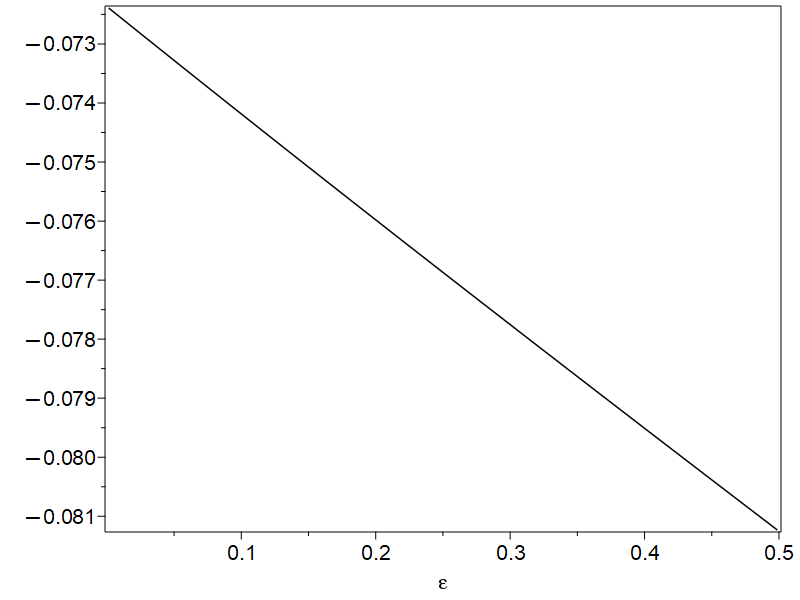

```python
plot(eval( (y2[1]/better2 - 1)/ep^1.0, x=0.4), ep=1.0e-4..0.5 );
```

```python
latex(betterres2);
```

```
-\frac{-8 \,{\mathrm e}^{-\frac{x}{2}} \sqrt{2} \varepsilon^{7}-{\mathrm e}^{-x} \varepsilon^{8}+64 \,{\mathrm e}^{\frac{x}{2}} \sqrt{2} \varepsilon^{5}+48 \varepsilon^{6}-1600 \,{\mathrm e}^{x} \varepsilon^{4}}{512 \left(-\varepsilon^{2}+8 \,{\mathrm e}^{x}\right)^{2}}
```

Here $Q(x) = 1+x^4$.

```python
F3 := simplify( int( res3/ep^2/sqrt(1+x^4)/2, x) ) assuming x>0;
```

$$\frac{\left(-\frac{1}{32}+\frac{\mathrm{I}}{32}\right) \sqrt{2} \left(2 \left(\mathrm{I} E\left(\left(\frac{1}{2}+\frac{\mathrm{I}}{2}\right) x \sqrt{2}, \mathrm{I}\right)+F\left(\left(\frac{1}{2}-\frac{\mathrm{I}}{2}\right) x \sqrt{2}, \mathrm{I}\right)\right) \sqrt{1+\mathrm{I} x^{2}} \left(x^{4}+1\right) \sqrt{1-\mathrm{I} x^{2}}+\left(1+\mathrm{I}\right) \sqrt{2} x^{3} \left(x^{4}+\frac{13}{3}\right)\right) \left(x^{4}+1\right)^{\frac{5}{2}}}{\left(x^{2}+\mathrm{I}\right)^{4} \left(\mathrm{I}-x^{2}\right)^{4}}$$

```python
better3 := y3[1]*(1+x^4)^(1/4)*(1+x^4-res3)^(-1/4)/exp(ep*F3): # Horrible to look at
```

$$\frac{{\mathrm e}^{\frac{\left(\frac{1}{12}-\frac{\mathrm{I}}{12}\right) \left(\mathrm{I} \sqrt{2} x^{5}+\sqrt{2} x^{5}+4 \sqrt{1-\mathrm{I} x^{2}} \sqrt{1+\mathrm{I} x^{2}} F\left(\left(\frac{1}{2}+\frac{\mathrm{I}}{2}\right) x \sqrt{2}, \mathrm{I}\right)+\mathrm{I} x \sqrt{2}+x \sqrt{2}\right) \sqrt{2}}{\sqrt{x^{4}+1} \varepsilon}}}{\left(x^{4}-\frac{\left(2 x^{4}-3\right) x^{2} \varepsilon^{2}}{\left(x^{2}+\mathrm{I}\right)^{2} \left(\mathrm{I}-x^{2}\right)^{2}}+1\right)^{\frac{1}{4}} {\mathrm e}^{\frac{\left(-\frac{1}{32}+\frac{\mathrm{I}}{32}\right) \varepsilon \sqrt{2} \left(2 \left(\mathrm{I} E\left(\left(\frac{1}{2}+\frac{\mathrm{I}}{2}\right) x \sqrt{2}, \mathrm{I}\right)+F\left(\left(\frac{1}{2}-\frac{\mathrm{I}}{2}\right) x \sqrt{2}, \mathrm{I}\right)\right) \sqrt{1+\mathrm{I} x^{2}} \left(x^{4}+1\right) \sqrt{1-\mathrm{I} x^{2}}+\left(1+\mathrm{I}\right) \sqrt{2} x^{3} \left(x^{4}+\frac{13}{3}\right)\right) \left(x^{4}+1\right)^{\frac{5}{2}}}{\left(x^{2}+\mathrm{I}\right)^{4} \left(\mathrm{I}-x^{2}\right)^{4}}}}$$

```python
betterres3 := simplify( ep^2*diff(better3,x,x)/better3-(1+x^4)) assuming x>0, ep>0;
```

```
kilobytes used=1207928, alloc=32304, time=117.05
```

$$\frac{28 \varepsilon^{4} \left(x^{4}+1\right)^{7} \left(-\frac{3}{56}-\frac{3 \varepsilon \left(x^{4}+1\right)^{\frac{3}{2}} x^{3} \left(x^{4}-\frac{3}{2}\right) \left(x^{12}+3 x^{8}-2 x^{6} \varepsilon^{2}+3 x^{4}+3 x^{2} \varepsilon^{2}+1\right) \left(x^{8}-\frac{7}{2} x^{4}+\frac{1}{2}\right)}{14}+x^{36}+\frac{3 x^{32}}{56}-\frac{13 x^{30} \varepsilon^{2}}{28}-\frac{285 x^{28}}{16}+\frac{18 x^{26} \varepsilon^{2}}{7}+\frac{\left(-\frac{2915}{8}+\varepsilon^{4}\right) x^{24}}{7}+\frac{867 x^{22} \varepsilon^{2}}{112}+\frac{3 \left(-\frac{2287}{16}-2 \varepsilon^{4}\right) x^{20}}{7}+\frac{725 x^{18} \varepsilon^{2}}{112}+\frac{9 \left(-\frac{83}{2}+3 \varepsilon^{4}\right) x^{16}}{14}+\frac{165 x^{14} \varepsilon^{2}}{28}+\frac{\left(\frac{811}{8}-27 \varepsilon^{4}\right) x^{12}}{14}+\frac{111 x^{10} \varepsilon^{2}}{14}+\frac{9 \left(65+\frac{9 \varepsilon^{4}}{2}\right) x^{8}}{56}+\frac{453 x^{6} \varepsilon^{2}}{112}+\frac{285 x^{4}}{112}+\frac{27 x^{2} \varepsilon^{2}}{112}\right)}{\left(x^{12}+3 x^{8}-2 x^{6} \varepsilon^{2}+3 x^{4}+3 x^{2} \varepsilon^{2}+1\right)^{2} \left(x^{2}+\mathrm{I}\right)^{12} \left(x^{2}-\mathrm{I}\right)^{12}}$$

```python
facs := factors( simplify( denom(betterres3)/(x^2+I)^12/(x^2-I)^12) );
```

| 4 | [[x^12+3*x^8-2*x^6*varepsilon^2+3*x^4+3*x^2*varepsilon^2+1, 2]] |
| --- | --- |

```python
possiblyzero := facs[2][1][1];
```

$$x^{12}+3 x^{8}-2 x^{6} \varepsilon^{2}+3 x^{4}+3 x^{2} \varepsilon^{2}+1$$

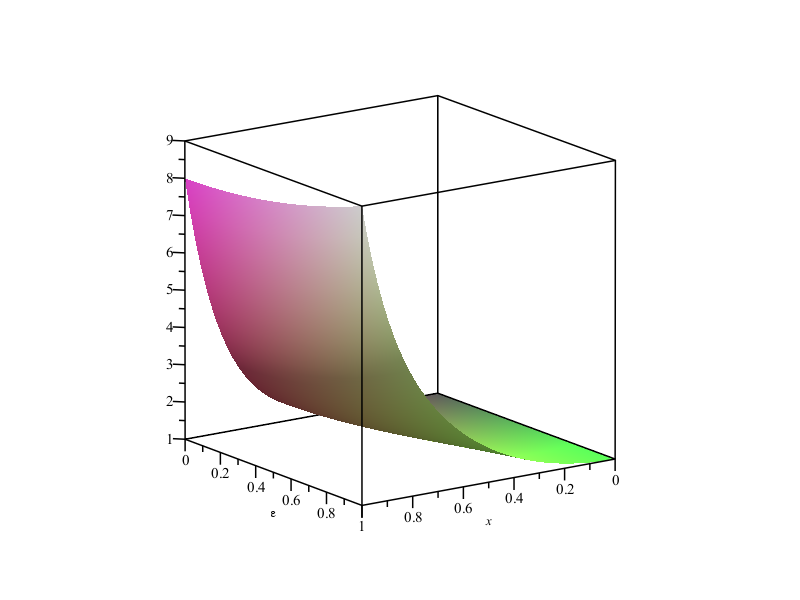

```python
plot3d( possiblyzero, x=0..1, ep=0..1 );
```

```python
fsolve( eval(possiblyzero,ep=0.0001), x);
```

```python
fs := factors(diff(possiblyzero,x));
```

| 12 | [[x, 1], [x^10+2*x^6-x^4*varepsilon^2+x^2+1/2*varepsilon^2, 1]] |
| --- | --- |

I wonder whether the exact solutions are possible? Yes, yes they are.

```python
dsolve( ep^2*diff(u1(x),x,x) - cosh(x)*u1(x), u1(x) );
```

$$\mathit{u1} \left(x \right) = c_{1} C\left(0, -\frac{2}{\varepsilon^{2}}, \frac{\mathrm{I}}{2} x \right)+c_{2} S\left(0, -\frac{2}{\varepsilon^{2}}, \frac{\mathrm{I}}{2} x \right)$$

Those are Mathieu functions. Since Maple doesn't know the asymptotics of those, that's as far as the exact solution can take us.

```python
dsolve( ep^2*diff(u2(x),x,x) - exp(x)/2*u2(x), u2(x) );
```

$$\mathit{u2} \left(x \right) = c_{1} I_{0}\left(\frac{\sqrt{2} {\mathrm e}^{\frac{x}{2}}}{\varepsilon}\right)+c_{2} K_{0}\left(\frac{\sqrt{2} {\mathrm e}^{\frac{x}{2}}}{\varepsilon}\right)$$

Ok, Bessel functions.

```python
dsolve( ep^2*diff(u2(x),x,x) - (1+x^4)*u2(x), u2(x) );
```

$$\mathit{u2} \left(x \right) = c_{1} {\mathrm e}^{-\frac{x^{3}}{3 \varepsilon}} \mathit{HT}\left(-\frac{12^{\frac{2}{3}}}{4 \varepsilon^{\frac{4}{3}}}, 0, 0, \frac{3^{\frac{2}{3}} 2^{\frac{1}{3}} x}{3 \varepsilon^{\frac{1}{3}}}\right)+c_{2} {\mathrm e}^{-\frac{x^{3}}{3 \varepsilon}} \mathit{HT}\left(-\frac{12^{\frac{2}{3}}}{4 \varepsilon^{\frac{4}{3}}}, 0, 0, \frac{3^{\frac{2}{3}} 2^{\frac{1}{3}} x}{3 \varepsilon^{\frac{1}{3}}}\right) \left(\int \frac{{\mathrm e}^{\frac{2 x^{3}}{3 \varepsilon}}}{\mathit{HT}\left(-\frac{12^{\frac{2}{3}}}{4 \varepsilon^{\frac{4}{3}}}, 0, 0, \frac{3^{\frac{2}{3}} 2^{\frac{1}{3}} x}{3 \varepsilon^{\frac{1}{3}}}\right)^{2}}d x \right)$$

I have *no idea* what those HT functions are, and in any event, one of the solutions is expressed only by quadrature. Looking them up, they are "Heun T functions" so there is some knowledge about them, anyway.

Now do the next question. \begin{equation}\label{eq:ParabolicCylinder} \e^2 y'' = \left(\frac{x^2}{4} + a \right) y\>. \end{equation} In Maple, two linearly independent solutions are called **CylinderU** and **CylinderV**. Notice that this equation has two turning points if $a<0$ and a double turning point if $a=0$. Show that the residual is $\e^2(3x^2-8a)/(4(x^2+4a)^2)y$. Discuss.

```python
(y,res) := WKB2Q( x->x^2/4+a, x, varepsilon ):
y[1];
```

$$\frac{{\mathrm e}^{\frac{-a \ln \left(2\right)-\frac{a \ln \left(a \right)}{2}+\frac{x \sqrt{x^{2}+4 a}}{4}+a \ln \left(x +\sqrt{x^{2}+4 a}\right)}{\varepsilon}}}{\left(\frac{x^{2}}{4}+a \right)^{\frac{1}{4}}}$$

```python
y[2], res;
```

$$\frac{{\mathrm e}^{-\frac{-a \ln \left(2\right)-\frac{a \ln \left(a \right)}{2}+\frac{x \sqrt{x^{2}+4 a}}{4}+a \ln \left(x +\sqrt{x^{2}+4 a}\right)}{\varepsilon}}}{\left(\frac{x^{2}}{4}+a \right)^{\frac{1}{4}}}$$

,$$-\frac{\varepsilon^{2} \left(-3 x^{2}+8 a \right)}{4 \left(x^{2}+4 a \right)^{2}}$$

```python
latex(res);
```

```
-\frac{\varepsilon^{2} \left(-3 x^{2}+8 a \right)}{4 \left(x^{2}+4 a \right)^{2}}
```

```python
map(limit,y, a=0, right )
```

| exp(1/4*x*(x^2)^(1/2)/varepsilon)/(x^2)^(1/4)*2^(1/2) | exp(-1/4*x*(x^2)^(1/2)/varepsilon)/(x^2)^(1/4)*2^(1/2) |
| --- | --- |

```python
simplify( ep^2*diff(CylinderV(0,x/sqrt(ep)),x,x) - x^2*CylinderV(0,x/sqrt(ep))/4 );
```

$$0$$

```
        [CylinderV(0, x 13   ) Pi    13   , CylinderU(0, x 13   ) 2    13   ]
```

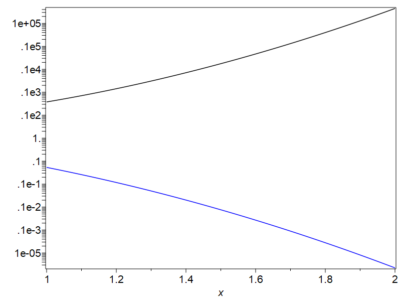

```python
refs := eval( [CylinderV(0,x/sqrt(ep))*sqrt(Pi)/ep^(1/4),
CylinderU(0,x/sqrt(ep))*sqrt(2)/ep^(1/4)], ep=1/13 );
pref := plots[logplot]( refs, x=1..2, colour=[black,blue] );
```

```python
yv := limit(y[1],a=0,right);
```

$$\frac{{\mathrm e}^{\frac{x \sqrt{x^{2}}}{4 \varepsilon}} \sqrt{2}}{\left(x^{2}\right)^{\frac{1}{4}}}$$

```python
yu := limit(y[2],a=0,right);
```

$$\frac{{\mathrm e}^{-\frac{x \sqrt{x^{2}}}{4 \varepsilon}} \sqrt{2}}{\left(x^{2}\right)^{\frac{1}{4}}}$$

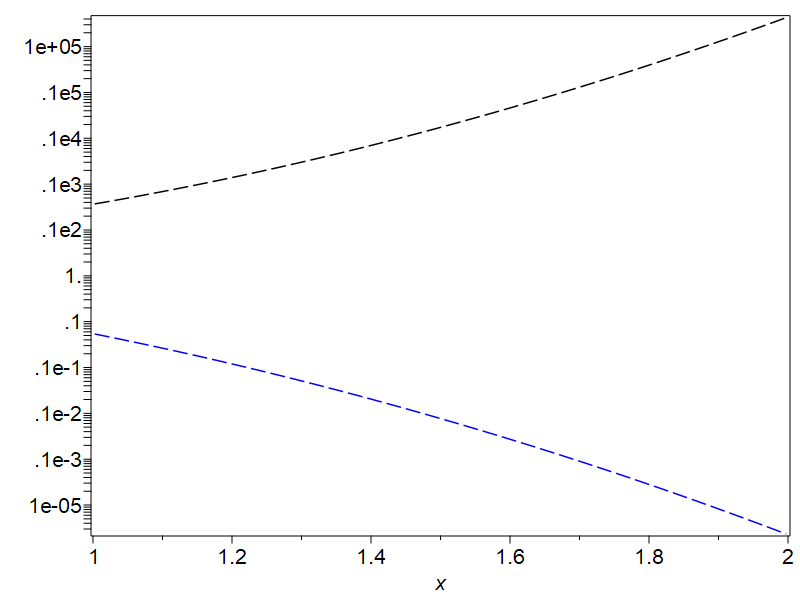

```python
wkbs := eval([yv,yu], ep=1/13):
pwkb := plots[logplot]( wkbs, x=1..2, colour=[black,blue],
 linestyle=3 );
```

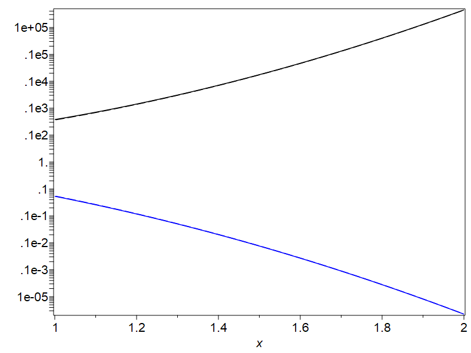

```python
plots[display]( pref,pwkb );
```

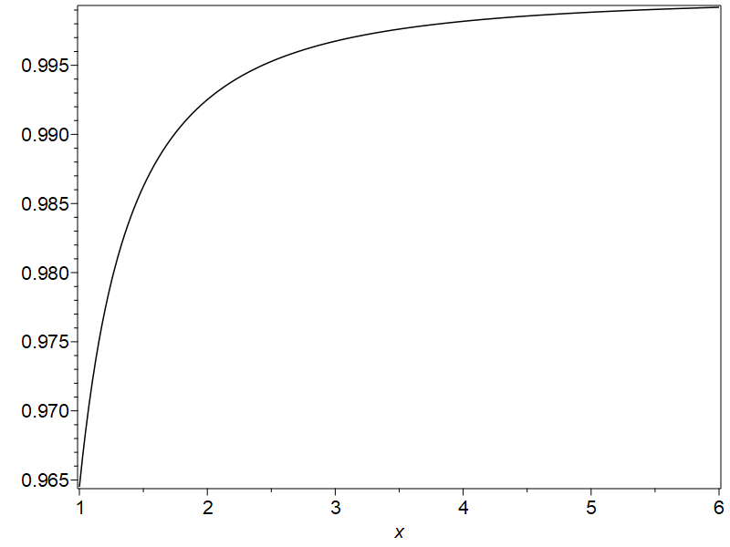

```python
plot( (wkbs[1])/refs[1], x=1..6);
```

```
                                 Digits := 20
```

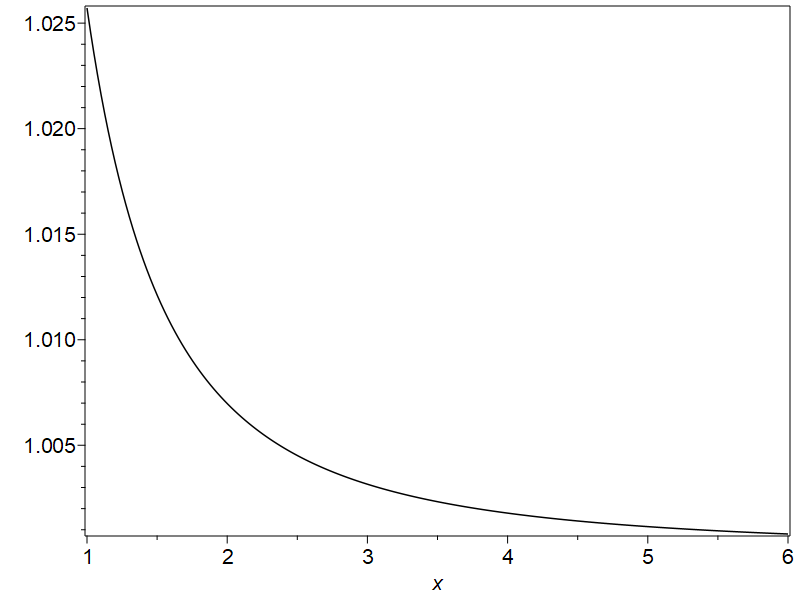

```python
Digits := 20;
plot( (wkbs[2])/refs[2], x=1..6);
```

```python
MultiSeries:-asympt( wkbs[2]/refs[2], x );
```

$$1+\frac{3}{104 x^{2}}-\frac{87}{21632 x^{4}}+\frac{2889}{2249728 x^{6}}+O\left(\frac{1}{x^{7}}\right)$$

```python
WKB2Q( x->1+x^2, x, varepsilon );
```

```
kilobytes used=1267009, alloc=38360, time=123.41
```

| exp((1/2*x*(x^2+1)^(1/2)+1/2*arcsinh(x))/varepsilon)/(x^2+1)^(1/4) | exp(-(1/2*x*(x^2+1)^(1/2)+1/2*arcsinh(x))/varepsilon)/(x^2+1)^(1/4) |
| --- | --- |

,$$\frac{\varepsilon^{2} \left(3 x^{2}-2\right)}{4 \left(x^{2}+1\right)^{2}}$$

```python
WKB2Q( x->exp(-x), x, varepsilon );
```

| exp((2-2*exp(-x)^(1/2))/varepsilon)/exp(-x)^(1/4) | exp(-(2-2*exp(-x)^(1/2))/varepsilon)/exp(-x)^(1/4) |
| --- | --- |

,$$\frac{\varepsilon^{2}}{16}$$

```python
#WKB2Q( x->1/x^2, x, varepsilon ); # Took a long time, and properly choked
```

```python
WKB2Q( x->1/x^2, x, varepsilon, a=1) assuming x>0;
```

| exp(ln(x)/varepsilon)/(1/x^2)^(1/4) | exp(-ln(x)/varepsilon)/(1/x^2)^(1/4) |
| --- | --- |

,$$-\frac{\varepsilon^{2}}{4 x^{2}}$$

```python
# WKB2Q( x->cos(x), x, varepsilon, a=0) assuming x>0;
```

```python
(y,res) := WKB2Q( x->1/(1+x^2), x, varepsilon ) assuming x>0;
```

| exp(arcsinh(x)/varepsilon)/(1/(x^2+1))^(1/4) | exp(-arcsinh(x)/varepsilon)/(1/(x^2+1))^(1/4) |
| --- | --- |

,$$-\frac{\varepsilon^{2} \left(x^{2}-2\right)}{4 \left(x^{2}+1\right)^{2}}$$

```python
hey := simplify( convert(y[1],ln) ) assuming varepsilon > 0, x>0;
```

$$\left(x +\sqrt{x^{2}+1}\right)^{\frac{1}{\varepsilon}} \left(x^{2}+1\right)^{\frac{1}{4}}$$

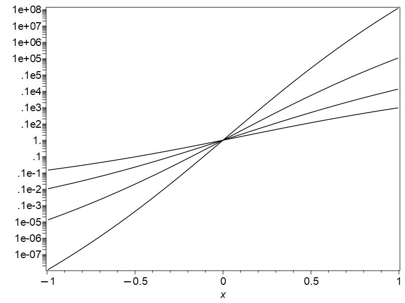

```python
plots[logplot]( [seq(eval(hey,varepsilon=e),e=[1/5,1/8,1/13,1/21])],x=-1..1 );
```

```python
macro(ep=varepsilon):
de := y -> ep^2*diff(y,x,x) - y/(1+x^2);
y := 'y':
dey := de(y(x));
#dsolve( de(y(x)), y(x));
```

```
                                       \dx      /   x  + 1
```

$$\varepsilon^{2} \left(\frac{d^{2}}{d x^{2}}y \left(x \right)\right)-\frac{y \left(x \right)}{x^{2}+1}$$

```python
dsolve( de(y(x)), y(x));
```

$$y \left(x \right) = c_{1} \left(x^{2}+1\right) {}_{2}^{}{\moversetsp{}{\mundersetsp{}{F_{1}^{}}}}\left(-\frac{\sqrt{\varepsilon +2 \,\mathrm{I}} \sqrt{\varepsilon -2 \,\mathrm{I}}-3 \varepsilon}{4 \varepsilon},\frac{3 \varepsilon +\sqrt{\varepsilon +2 \,\mathrm{I}} \sqrt{\varepsilon -2 \,\mathrm{I}}}{4 \varepsilon};\frac{1}{2};-x^{2}\right)+c_{2} \left(x^{2}+1\right) {}_{2}^{}{\moversetsp{}{\mundersetsp{}{F_{1}^{}}}}\left(-\frac{\sqrt{\varepsilon +2 \,\mathrm{I}} \sqrt{\varepsilon -2 \,\mathrm{I}}-5 \varepsilon}{4 \varepsilon},\frac{5 \varepsilon +\sqrt{\varepsilon +2 \,\mathrm{I}} \sqrt{\varepsilon -2 \,\mathrm{I}}}{4 \varepsilon};\frac{3}{2};-x^{2}\right) x$$

```python
(y,res) := WKB2Q( x->cosh(x), x, varepsilon ) assuming x>0:
y[1];
```

$$\frac{{\mathrm e}^{\frac{\sqrt{2} \Pi \left(\sqrt{\frac{\cosh \left(x \right)-1}{\cosh \left(x \right)}}, 1, \frac{\sqrt{2}}{2}\right)}{\varepsilon}}}{\cosh \left(x \right)^{\frac{1}{4}}}$$

```python
res;
```

$$-\frac{\varepsilon^{2} \left(5 \mathrm{sech}\left(x \right)^{2}-1\right)}{16}$$

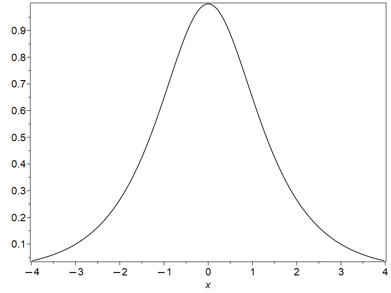

```python
plot(sech(x), x=-4..4);
```

```python
int( sqrt(cosh(xi)), xi=0..x) assuming x>0;
```

$$\sqrt{2} \Pi \left(\sqrt{\frac{\cosh \left(x \right)-1}{\cosh \left(x \right)}}, 1, \frac{\sqrt{2}}{2}\right)$$

```python
(y,res) := WKB2Q( x->exp(x)/2, x, varepsilon ):
y[1];
```

$$\frac{{\mathrm e}^{\frac{-\sqrt{2}+\sqrt{2} \sqrt{{\mathrm e}^{x}}}{\varepsilon}} 2^{\frac{1}{4}}}{\left({\mathrm e}^{x}\right)^{\frac{1}{4}}}$$

```python
res;
```

$$\frac{\varepsilon^{2}}{16}$$

```python
(y,res) := WKB2Q( x->1+x^4, x, varepsilon ):
y[1];
```

$$\frac{{\mathrm e}^{\frac{\left(\frac{1}{12}-\frac{\mathrm{I}}{12}\right) \left(\mathrm{I} \sqrt{2} x^{5}+\sqrt{2} x^{5}+4 \sqrt{1-\mathrm{I} x^{2}} \sqrt{1+\mathrm{I} x^{2}} F\left(\left(\frac{1}{2}+\frac{\mathrm{I}}{2}\right) x \sqrt{2}, \mathrm{I}\right)+\mathrm{I} x \sqrt{2}+x \sqrt{2}\right) \sqrt{2}}{\sqrt{x^{4}+1} \varepsilon}}}{\left(x^{4}+1\right)^{\frac{1}{4}}}$$

```python
res;
```

$$\frac{\left(2 x^{4}-3\right) x^{2} \varepsilon^{2}}{\left(x^{2}+\mathrm{I}\right)^{2} \left(\mathrm{I}-x^{2}\right)^{2}}$$

```python
(y,res) := WKB2Q( x->x*(1+x^2)^2, x, varepsilon ) assuming x>0:
y[1];
```

$$\frac{{\mathrm e}^{\frac{\frac{2 x^{\frac{7}{2}}}{7}+\frac{2 x^{\frac{3}{2}}}{3}}{\varepsilon}}}{{\left(x \left(x^{2}+1\right)^{2}\right)}^{\frac{1}{4}}}$$

```python
res;
```

$$\frac{\varepsilon^{2} \left(45 x^{4}+2 x^{2}+5\right)}{16 x^{2} \left(x^{2}+1\right)^{2}}$$

```python
(y,res) := WKB2Q( x->sqrt(x), x, varepsilon ):
res;
```

$$\frac{9 \varepsilon^{2}}{64 x^{2}}$$

```python
latex(y[1]);
```

```
\frac{{\mathrm e}^{\frac{4 x^{\frac{5}{4}}}{5 \varepsilon}}}{x^{\frac{1}{8}}}
```

```python
y[1];
```

$$\frac{{\mathrm e}^{\frac{4 x^{\frac{5}{4}}}{5 \varepsilon}}}{x^{\frac{1}{8}}}$$

```python
(y,res) := WKB2Q( x->(ln(x)/x)^2, x, varepsilon, a=1 ):
res;
```

```
kilobytes used=1294756, alloc=38360, time=126.31
```

$$-\frac{\varepsilon^{2} \left(\ln \left(x \right)^{2}-3\right)}{4 \ln \left(x \right)^{2} x^{2}}$$

```python
latex(res);
```

```
-\frac{\varepsilon^{2} \left(\ln \left(x \right)^{2}-3\right)}{4 \ln \left(x \right)^{2} x^{2}}
```

```python
ratui := coeff(res,ep,2)/(ln(x)/x)^2;
```

$$-\frac{\ln \left(x \right)^{2}-3}{4 \ln \left(x \right)^{4}}$$

```python
ah := simplify( y[2] ) assuming x>1;
```

$$\frac{{\mathrm e}^{-\frac{\ln \left(x \right)^{2}}{2 \varepsilon}} \sqrt{x}}{\sqrt{\ln \left(x \right)}}$$

```python
latex(ah);
```

```
\frac{{\mathrm e}^{-\frac{\ln \left(x \right)^{2}}{2 \varepsilon}} \sqrt{x}}{\sqrt{\ln \left(x \right)}}
```

```python
(y,res) := WKB2Q( x->1+x^2, x, varepsilon, a=1 ):
res;
```

$$\frac{\varepsilon^{2} \left(3 x^{2}-2\right)}{4 \left(x^{2}+1\right)^{2}}$$

```python
WKB4Q := proc( Q::operator, Qorig::operator, x, eps, {a:=0})
 local xi, residual, Qt, S, y;
 Qt := unapply( convert(series(sqrt(Q(xi)),ep,5),polynom), xi );
 S := int( Qt(xi), xi=a..x )  assuming x>a;
 y := exp(S/eps)*Q(x)^(-1/4);
 residual := simplify( eps^2*diff(y,x,x)/y-Qorig(x));
 y := [y ,exp(-S/eps)*Q(x)^(-1/4)];
 return y, residual
end:
```

```python
Qtilde := unapply( 1+x^2 - res, x );
(y4,res4) := WKB4Q( Qtilde, x->1+x^2, x, varepsilon, a=1 ):
res4;
```

```
                                            (1 + x )
```

$$\frac{9 \varepsilon^{4} \left(-\frac{9 \varepsilon^{3} \left(x^{2}-\frac{2}{3}\right)^{2} \left(x^{6}+3 x^{4}+\left(-\frac{3 \varepsilon^{2}}{4}+3\right) x^{2}+\frac{\varepsilon^{2}}{2}+1\right) x \left(x^{2}+1\right)^{\frac{9}{2}} \left(x^{2}-\frac{3}{2}\right)}{128}+x^{28}+\frac{19 x^{26}}{2}+\left(-\frac{29 \varepsilon^{2}}{256}+\frac{145}{4}\right) x^{24}+\left(-\frac{139 \varepsilon^{2}}{256}+58\right) x^{22}+\left(\frac{25}{128} \varepsilon^{2}-\frac{77}{2}-\frac{135}{8192} \varepsilon^{4}\right) x^{20}+\left(-\frac{225}{4096} \varepsilon^{4}+\frac{2195}{288} \varepsilon^{2}-\frac{781}{2}\right) x^{18}+\left(\frac{81}{16384} \varepsilon^{6}+\frac{3365}{128} \varepsilon^{2}-\frac{3729}{4}-\frac{225}{8192} \varepsilon^{4}\right) x^{16}+\left(-\frac{27}{16384} \varepsilon^{6}+\frac{175}{2048} \varepsilon^{4}+\frac{6251}{128} \varepsilon^{2}-1320\right) x^{14}+\left(\frac{81}{131072} \varepsilon^{8}-\frac{207}{16384} \varepsilon^{6}+\frac{2821}{48} \varepsilon^{2}-1254+\frac{2125}{24576} \varepsilon^{4}\right) x^{12}+\left(-\frac{81}{32768} \varepsilon^{8}+\frac{111}{16384} \varepsilon^{6}-\frac{185}{4096} \varepsilon^{4}+\frac{3155}{64} \varepsilon^{2}-\frac{1639}{2}\right) x^{10}+\left(\frac{135}{32768} \varepsilon^{8}+\frac{85}{8192} \varepsilon^{6}-\frac{1441}{4}-\frac{575}{8192} \varepsilon^{4}+\frac{7715}{256} \varepsilon^{2}\right) x^{8}+\left(-\frac{15}{4096} \varepsilon^{8}-\frac{49}{6144} \varepsilon^{6}-98+\frac{10615}{768} \varepsilon^{2}+\frac{25}{3072} \varepsilon^{4}\right) x^{6}+\left(\frac{15}{8192} \varepsilon^{8}-\frac{1}{512} \varepsilon^{6}-\frac{25}{2}+\frac{25}{1024} \varepsilon^{4}+\frac{603}{128} \varepsilon^{2}\right) x^{4}+\left(\frac{3}{1024} \varepsilon^{6}-\frac{1}{2048} \varepsilon^{8}+\frac{69}{64} \varepsilon^{2}+\frac{1}{2}\right) x^{2}+\frac{\left(\varepsilon^{2}+2\right) \left(\varepsilon^{6}-14 \varepsilon^{4}-32 \varepsilon^{2}+2304\right)}{18432}\right)}{2 \left(x^{6}+3 x^{4}+\left(-\frac{3 \varepsilon^{2}}{4}+3\right) x^{2}+\frac{\varepsilon^{2}}{2}+1\right)^{2} \left(x^{2}+1\right)^{11}}$$

```python
fd := factors(denom(res4));
```

| 262144 | [[x^6+3*x^4+3*x^2-3/4*x^2*varepsilon^2+1/2*varepsilon^2+1, 2], [x^2+1, 11]] |
| --- | --- |

```python
fd[2][1][1];
```

$$x^{6}+3 x^{4}+3 x^{2}-\frac{3}{4} x^{2} \varepsilon^{2}+\frac{1}{2} \varepsilon^{2}+1$$

```python
discrim( fd[2][1][1], x);
```

$$-\frac{729 \left(\varepsilon^{2}+2\right) \varepsilon^{8} \left(\varepsilon^{2}-25\right)^{2}}{8}$$

So if $\e = 5$, then there multiple roots of the denominator (and therefore spurious turning points).

```python
factor( limit( denom(res4), ep=0, right) );
```

$$262144 \left(x^{2}+1\right)^{17}$$

```python
factor( limit( denom(res4), ep=5, left) );
```

$$16384 \left(x^{2}+1\right)^{11} \left(x^{2}+6\right)^{2} \left(2 x^{2}-3\right)^{4}$$

So if $\e = 5$ then there are two real roots $x = \pm \sqrt{3/2}$ of the altered $Q(x)$, meaning that these are spurious turning points.

```python
y4[1];
```

$$\frac{{\mathrm e}^{\frac{1229 \sqrt{2} \varepsilon^{4} \left(x^{2}+1\right)^{\frac{9}{2}}-1792 x^{9} \varepsilon^{4}-13440 \sqrt{2} \varepsilon^{2} \left(x^{2}+1\right)^{\frac{9}{2}}+92160 x^{11}+7680 x^{9} \varepsilon^{2}-8064 x^{7} \varepsilon^{4}-92160 \sqrt{2} \left(x^{2}+1\right)^{\frac{9}{2}}+92160 \,\mathrm{arcsinh}\left(x \right) \left(x^{2}+1\right)^{\frac{9}{2}}-92160 \ln \left(1+\sqrt{2}\right) \left(x^{2}+1\right)^{\frac{9}{2}}+460800 x^{9}+69120 x^{7} \varepsilon^{2}-14112 x^{5} \varepsilon^{4}+921600 x^{7}+161280 x^{5} \varepsilon^{2}-9600 x^{3} \varepsilon^{4}+921600 x^{5}+145920 x^{3} \varepsilon^{2}-5760 x \,\varepsilon^{4}+460800 x^{3}+46080 x \,\varepsilon^{2}+92160 x}{184320 \left(x^{2}+1\right)^{\frac{9}{2}} \varepsilon}}}{\left(x^{2}-\frac{\varepsilon^{2} \left(3 x^{2}-2\right)}{4 \left(x^{2}+1\right)^{2}}+1\right)^{\frac{1}{4}}}$$

```python
discrim( numer( denom(y4[1])^4 ), x );
```

$$-95551488 \left(\varepsilon^{2}+2\right) \varepsilon^{8} \left(\varepsilon^{2}-25\right)^{2}$$

```python
y[1];
```

$$\frac{{\mathrm e}^{\frac{-\frac{\sqrt{2}}{2}-\frac{\ln \left(1+\sqrt{2}\right)}{2}+\frac{x \sqrt{x^{2}+1}}{2}+\frac{\mathrm{arcsinh}\left(x \right)}{2}}{\varepsilon}}}{\left(x^{2}+1\right)^{\frac{1}{4}}}$$

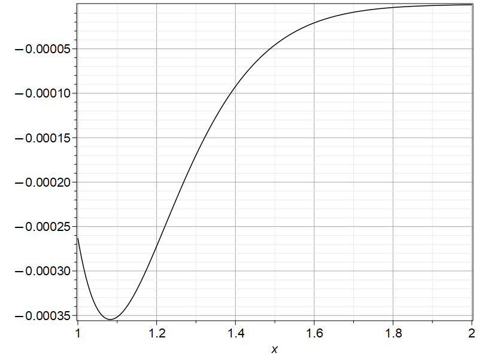

```python
plot( eval(y[2]-y4[2],ep=1/5) , x=1..2, gridlines );
```

```
kilobytes used=1315756, alloc=38360, time=128.89
```

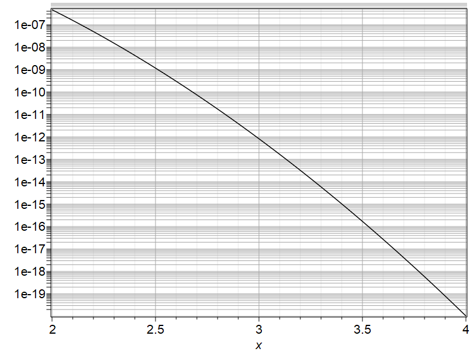

```python
plots[logplot]( abs(eval(y[2]-y4[2],ep=1/5)) , x=2..4, gridlines );
```

The final exercise, exploring an oscillatory solution.

```python
(y,res) := WKB2Q( x->-(1+x), x, ep );
```

| exp((-2/3*I-2/3*(-1-x)^(3/2))/varepsilon)/(-1-x)^(1/4) | exp(-(-2/3*I-2/3*(-1-x)^(3/2))/varepsilon)/(-1-x)^(1/4) |
| --- | --- |

,$$\frac{5 \varepsilon^{2}}{16 \left(1+x \right)^{2}}$$

```python
yinit := eval(y,x=0);
```

| -(-1)^(3/4) | -(-1)^(3/4) |
| --- | --- |

```python
evalc( (-1)^(1/4) );
```

$$\frac{\sqrt{2}}{2}+\frac{\mathrm{I} \sqrt{2}}{2}$$

```python
evalc( yinit );
```

| 1/2*2^(1/2)-1/2*I*2^(1/2) | 1/2*2^(1/2)-1/2*I*2^(1/2) |
| --- | --- |

We want $c_1 y_1 + c_2 y_2 $ to be real for $x>0$. The easiest way to do that is to replace $(-1-x)^{1/4}$ by $(1+x)^{1/4}$.

```python
y := [exp(( 2/3*I-2/3*I*(1+x)^(3/2))/varepsilon)/(1+x)^(1/4),
      exp((-2/3*I+2/3*I*(1+x)^(3/2))/varepsilon)/(1+x)^(1/4)];
```

| exp((2/3*I-2/3*I*(1+x)^(3/2))/varepsilon)/(1+x)^(1/4) | exp((-2/3*I+2/3*I*(1+x)^(3/2))/varepsilon)/(1+x)^(1/4) |
| --- | --- |

```python
eval(y,x=0);
```

| 1 | 1 |
| --- | --- |

```python
Y := simplify( evalc( y[1]+y[2] ) ) assuming x>0; # should be a cosine
```

```
                                      (1 + x)
```

$$\frac{2 \cos \left(\frac{\frac{2 \sqrt{1+x} x}{3}+\frac{2 \sqrt{1+x}}{3}-\frac{2}{3}}{\varepsilon}\right)}{\left(1+x \right)^{\frac{1}{4}}}$$

```python
res := simplify(ep^2*diff(Y,x,x)/Y + (1+x));
```

$$\frac{5 \varepsilon^{2}}{16 \left(1+x \right)^{2}}$$

```
kilobytes used=1336592, alloc=42456, time=131.55
```

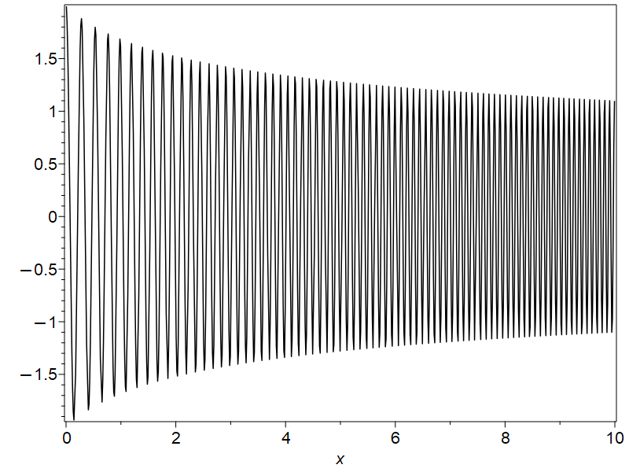

```python
plot( eval(Y,ep=1/21), x=0..10 );
```

```python
latex(Y);
```

```
\frac{2 \cos \left(\frac{\frac{2 \sqrt{1+x} x}{3}+\frac{2 \sqrt{1+x}}{3}-\frac{2}{3}}{\varepsilon}\right)}{\left(1+x \right)^{\frac{1}{4}}}
```

```python
(y78,res78) := WKB2Q( t->-(1+t^2), x, ep );
```

| exp((1/2*x*(-x^2-1)^(1/2)-1/2*arctan(1/(-x^2-1)^(1/2)*x))/varepsilon)/(-x^2-1)^(1/4) | exp(-(1/2*x*(-x^2-1)^(1/2)-1/2*arctan(1/(-x^2-1)^(1/2)*x))/varepsilon)/(-x^2-1)^(1/4) |
| --- | --- |

,$$\frac{\varepsilon^{2} \left(3 x^{2}-2\right)}{4 \left(x^{2}+1\right)^{2}}$$

```python
evalc(y78[1]) assuming x>0, ep>0;
```

$$\frac{\cos \left(\frac{\frac{x \sqrt{x^{2}+1}}{2}-\frac{\ln \left(\frac{{\left(-\frac{x}{\sqrt{x^{2}+1}}+1\right)}^{2}}{{\left(-\frac{x}{\sqrt{x^{2}+1}}-1\right)}^{2}}\right)}{8}}{\varepsilon}\right) \sqrt{2}}{2 \left(x^{2}+1\right)^{\frac{1}{4}}}+\frac{\sin \left(\frac{\frac{x \sqrt{x^{2}+1}}{2}-\frac{\ln \left(\frac{{\left(-\frac{x}{\sqrt{x^{2}+1}}+1\right)}^{2}}{{\left(-\frac{x}{\sqrt{x^{2}+1}}-1\right)}^{2}}\right)}{8}}{\varepsilon}\right) \sqrt{2}}{2 \left(x^{2}+1\right)^{\frac{1}{4}}}+\mathrm{I} \left(\frac{\sin \left(\frac{\frac{x \sqrt{x^{2}+1}}{2}-\frac{\ln \left(\frac{{\left(-\frac{x}{\sqrt{x^{2}+1}}+1\right)}^{2}}{{\left(-\frac{x}{\sqrt{x^{2}+1}}-1\right)}^{2}}\right)}{8}}{\varepsilon}\right) \sqrt{2}}{2 \left(x^{2}+1\right)^{\frac{1}{4}}}-\frac{\cos \left(\frac{\frac{x \sqrt{x^{2}+1}}{2}-\frac{\ln \left(\frac{{\left(-\frac{x}{\sqrt{x^{2}+1}}+1\right)}^{2}}{{\left(-\frac{x}{\sqrt{x^{2}+1}}-1\right)}^{2}}\right)}{8}}{\varepsilon}\right) \sqrt{2}}{2 \left(x^{2}+1\right)^{\frac{1}{4}}}\right)$$